# Relação de Acertos vs Notas no Enem

20/09/2020

## TRI

O texto introdutório - Fonte: https://guiadoestudante.abril.com.br/

Acertar muitas questões no Enem não é garantia de uma super nota, assim como não ir tão bem de acordo com o gabarito não significa que a nota vai ser baixa. Isso tudo porque a composição da nota leva em consideração a Teoria de Resposta ao Item (TRI), um complexo cálculo matemático que leva em conta, antes de tudo, a coerência dos acertos.

Segundo a TRI, um candidato que acerta mais questões difíceis do que fáceis é considerado incoerente. Isso porque a probabilidade de isso acontecer é muito baixa e dai conclui-se que ele chutou, o que diminui sua nota. Já uma prova considerada coerente, dentro do esperado, é aquela em que o candidato acerta muitas fáceis, algumas médias e poucas difíceis. Isso explica porque alguns candidatos acertam o mesmo número de questões e têm notas diferentes, ou porque alguns candidatos acertam menos questões do que outros e obtêm notas maiores.

O gráfico apresenta a relação entre o número de acertos no gabarito e a real nota do candidato no Enem de 2013 da Cidade de Santarém-PA. Os gráficos são resultado de uma pesquisa feita com 14.953 candidatos que participaram dos dois dias de prova e representa apenas a prova de Ciencias da Natureza e suas Tecnologias. Em breve postaremos os gráficos da relação Acertos vs Notas de todos os anos posteriores das provas de Matemática e Ciências da Natureza.

Iniciamos com o filtro para que a leitura seja apenas das variáveis que desejamos. Nesse caso utizamos o dicionário dos microdados para checar os respectivos nomes.

```r
colsToKeep <- c("COD_MUNICIPIO_RESIDENCIA","NO_MUNICIPIO_RESIDENCIA",
  "COD_UF_RESIDENCIA","UF_RESIDENCIA", "IN_PRESENCA_CN", "IN_PRESENCA_CH",
  "IN_PRESENCA_LC", "IN_PRESENCA_MT", "ID_PROVA_CN", "GABARITO_CN", "NOTA_CN", "TX_RESPOSTAS_CN")
```

Agora usamos a função fread no pacote data.table. Com ele o carregamento de grandes conjuntos de dados precisa de apenas alguns segundos.

```r
setwd("/mnt/10efef75-8353-46be-b050-2cb93c385aee/Microdados/Microdados_enem_2013/DADOS")
#setwd(dirname(rstudioapi::getActiveDocumentContext()$path))
df2 <- fread('MICRODADOS_ENEM_2013.csv', header=TRUE, select=colsToKeep, sep = ';', verbose=F)
# Usando o fread, dispensa o argumento sep, nrosw

## Retirando as linhas vazias. O canditato comparaceu mais nao respondeu (0 ou NA)
# APLICADO A TABELA
get.data <- df2[!is.na(df2$'NOTA_CN') & (df2$'NOTA_CN' != 0.0) & (df2$'IN_PRESENCA_CN' == 1)
  & (df2$'IN_PRESENCA_CH' == 1) & (df2$'IN_PRESENCA_LC' == 1) & (df2$'IN_PRESENCA_MT' == 1) &
    (df2$'NO_MUNICIPIO_RESIDENCIA'=="SANTAREM"),]

#Capacidade de gravação rápida paralelizada. Use isso caso deseje guardar em arquivo
fwrite(get.data, "dataEnem2013.csv")

# Dispensa a leitura. Comente caso use a variável  "get.data"
get.data.filt <- fread("dataEnem2013.csv")
```

## Filtrando as respostas e gabarito

Usamos o data.table() por ser mais rápido do que “dplyr” e “plyr”. Aqui filtramos apenas o gabarito da prova azul (COR = 171). Ela vai ser a prova default. Isso porque as questões nas demais provas estão em ordem diferentes. Aqui vamos organizar todas em uma mesma ordem. Se você não achar necessário, adote a metodologia mais adequada.

```r
# Respostas
set_all<-get.data.filt[,.(NO_MUNICIPIO_RESIDENCIA,COD_UF_RESIDENCIA, UF_RESIDENCIA, ID_PROVA_CN,
  NOTA_CN, TX_RESPOSTAS_CN)]

# Gabarito da prova azul.
set_gabarito <- get.data.filt[ID_PROVA_CN ==171, .(GABARITO_CN)]
```

```r
my_into<-c(paste('Q',46:90,sep=""))

#### Split: Separa as respostas e gabaritos por colunas. Pacote "tidyr" ####
get.split.all<-set_all %>% separate(TX_RESPOSTAS_CN, into=as.character(my_into), sep=1:length(my_into))
get.split.gab.cn<-set_gabarito %>% separate(GABARITO_CN, into=as.character(my_into), sep= 1:length(my_into))
```

Procure o help da função separate para entender cada argumento.

## Selecionando as questões correspondentes

Vamos selecionar a cor da prova e ordenar-las de acordo com a prova Azul. Exemplo: A questão 58 da prova amarela é a questão 46 da prova azul, etc. Essa reordenação é feita a partir dos arquivos disponíveis na pasta PLANILHAS.

```r
options(width = 200)
set_cor_azul<-get.split.all[(ID_PROVA_CN ==171), .(NO_MUNICIPIO_RESIDENCIA,COD_UF_RESIDENCIA,UF_RESIDENCIA, NOTA_CN,Q46, Q47, Q48, Q49, Q50, Q51,Q52, Q53, Q54, Q55, Q56, Q57, Q58, Q59, Q60,Q61,Q62,Q63, Q64, Q65, Q66, Q67, Q68, Q69, Q70, Q71, Q72, Q73, Q74, Q75,
  Q76, Q77, Q78, Q79, Q80, Q81, Q82, Q83, Q84, Q85, Q86, Q87, Q88, Q89, Q90)]
```

```r
set_cor_amarela<-get.split.all[(ID_PROVA_CN ==172), .(NO_MUNICIPIO_RESIDENCIA,COD_UF_RESIDENCIA,UF_RESIDENCIA, NOTA_CN, Q58,Q59,Q60,Q61,Q62,Q54,Q55,Q56,Q57,Q46,Q47,Q48,Q49,Q63,Q64,Q65,Q50,Q51,Q52,Q53,
  Q69,Q70,Q71,Q72,Q73,Q74,Q66,Q78,Q80,Q81,Q82,Q83,Q86, Q87,Q88,Q89,Q90,Q84,Q85,Q67,Q68,Q79,Q75,Q76,Q77)]
```

### Ordenar as provas

Agora vamos usar o “rbindlist” para unir todas as provas em sua devida ordem. Para isso, reorganizamos os heads das colunas. Usamos novamente a prova azul como referência. Aqui você pode adotar outras maneiras para organizar. Pra mim essa foi mais fácil.

Usamos o “rbindlist” por ser mais eficiente, considerando que estamos usando data.table(). Experimente usar o rbind (nativo) ou bind_rows, filter(), select() do dplyr. Chamo atenção aqui com os conflitos do pacote “tidyverse” e “MASS”. Veja sobre tidyverse_conflicts() em https://tidyverse.tidyverse.org/.

```r
azul_amarela <-rbindlist(list(set_cor_azul, set_cor_amarela), use.names=TRUE)
azul_amarela_branca <-rbindlist(list(azul_amarela, set_cor_branca), use.names=TRUE)
RespostasEnem2013<-rbindlist(list(azul_amarela_branca, set_cor_rosa), use.names=TRUE)
```

[output not shown]

## Conferindo o gabarito e respostas

Aqui nos capturamos apenas a primeira linha do gabarito da prova azul, já que todas as provas agora estão em ordem e o gabarito é único.

```r
# Guardando os dados de resposta em arquivo
fwrite(RespostasEnem2013, "RespostasEnem2013.csv")
# Guardando os dados de gabarito em arquivo
fwrite(get.split.gab.cn, "GabaritoEnem2013.csv")

#ignore a
get.respostas_all= fread("RespostasEnem2013.csv") #
get.gabarito_all =fread("GabaritoEnem2013.csv") #

set.only.line<-get.gabarito_all[1,]
```

Transformando a linha do gabarito em caracter e as respostas em matriz pois usaremos a função “mult.choice” do pacote “ltm”.

```r
key_azul<-as.character(set.only.line)

# Set matrix de resposta
set.respost<-as.matrix(get.respostas_all[,5:49]) # Set coluna onde estao as respostas
```

Agora checamos as respostas. Teremos 1 para acertos e 0 para erros.

```r
# Compara o gabarito
as.binary<-mult.choice(set.respost, key_azul)
```

e somaremos quantos acertos cada candidato obteve na prova. Em seguida adicionamos o numero de acertos no arquivo de respostas.

```r
n.acert.by.partip <-data.frame(rowSums(as.binary))

setnames(n.acert.by.partip, "Acertos")

RespostasEnem2013Enotas<-bind_cols(list(get.respostas_all, n.acert.by.partip))
```

## Gerando os gráficos

Inseri aqui uma espécie de categoria das notas. Você pode adequar como achar melhor. Exemplo:

```r
#df$Category[df$NOTA_CN >= 300 & df$NOTA_CN <= 420] = "Baixa"
```

Enfim, o gráfico da relação Nota vs Acertos da prova de Ciências da Natureza.

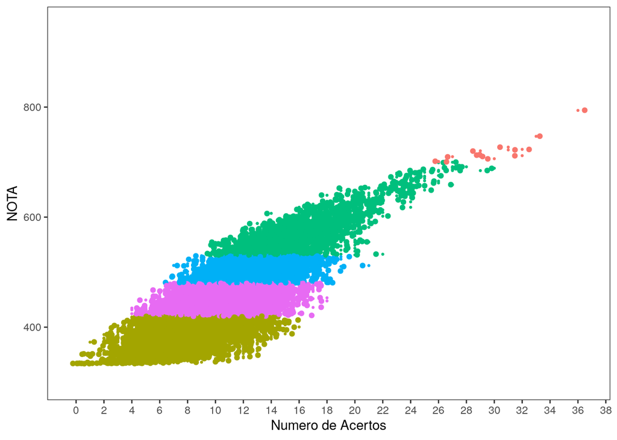

```r
#my_y<-df$NOTA_CN  # 2013

#df$Category = factor(df$Category)
#p0 <- ggplot(df, aes(x=Acertos, y=my_y,  colour=Category)) + geom_point(size=0.5) + theme_bw() +
#  scale_x_continuous(name="Numero de Acertos", breaks = seq(0,45,2)) +
#  scale_y_continuous(name="NOTA", breaks = seq(0,1000,200), limits = c(300,950))+
#  theme(panel.grid = element_blank(), legend.position = "none")  #+ scale_colour_manual(values=cbPalette) # +
#  #geom_smooth(method="lm")
#p0
```

O gráfico a seguir corresponde ao número de acertos dos candidatos.

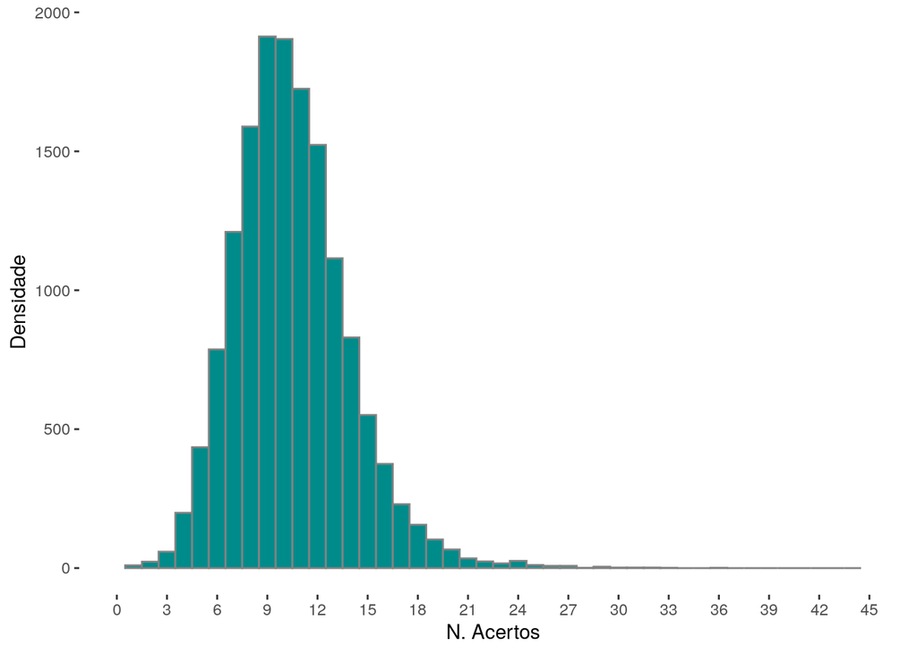

```r
g <- ggplot(df, aes(x=Acertos)) + geom_histogram(binwidth = 1, colour="grey51", fill="darkcyan") +
  scale_x_continuous(name="N. Acertos", breaks = seq(0,45,3), limits = c(0,45)) +
  scale_y_continuous(name="Densidade")  + theme(panel.border = element_blank(), panel.grid = element_blank(), panel.background = element_blank())
# + theme_bw()
g
```

É um material técnico. Espero que ainda assim ajude os iniciantes.

Nesse [link](https://rpubs.com/coliveira/803625) há um breve estudo sobre as notas de corte para acesso em cursos na Universidade Federal do Oeste do Pará por meio do ENEM.

Este conteúdo está disponível por meio da Licença Creative Commons 4.0